# Project 4: Anomaly Detection in Network Traffic Using Clustering

### Summary Statistics:

- **Records:** 9,537
- **Features:** 11
- **Missing Values:**
  - *encryption_used* has 1,966 missing entries; all other features are complete.

Descriptive statistics reveal that, for example, the average network packet size is approximately 500 bytes, and the average session duration is about 792 seconds. This data provides a robust foundation for unsupervised learning, especially since we are not relying solely on the provided attack labels during training.

```python
# Print dataset shape/info/missing values
print(f"Dataset Shape: {df.shape}\n")
print("Dataset Info:")
df.info()

print("\nMissing Values in Each Column:")
print(df.isnull().sum())

# Display descriptive statistics
print("\nDescriptive Statistics:")
display(df.describe())
```

```
Dataset Shape: (9537, 11)

Dataset Info:
<class 'pandas.core.frame.DataFrame'>
RangeIndex: 9537 entries, 0 to 9536
Data columns (total 11 columns):
 #   Column               Non-Null Count  Dtype
---  ------               --------------  -----
 0   session_id           9537 non-null   object
 1   network_packet_size  9537 non-null   int64
 2   protocol_type        9537 non-null   object
 3   login_attempts       9537 non-null   int64
 4   session_duration     9537 non-null   float64
 5   encryption_used      7571 non-null   object
 6   ip_reputation_score  9537 non-null   float64
 7   failed_logins        9537 non-null   int64
 8   browser_type         9537 non-null   object
 9   unusual_time_access  9537 non-null   int64
 10  attack_detected      9537 non-null   int64
dtypes: float64(2), int64(5), object(4)
memory usage: 819.7+ KB

Missing Values in Each Column:
session_id                0
network_packet_size       0
protocol_type             0
login_attempts            0
session_duration          0
encryption_used        1966
ip_reputation_score       0
failed_logins             0
browser_type              0
unusual_time_access       0
attack_detected           0
dtype: int64

Descriptive Statistics:
```

|  | network_packet_size | login_attempts | session_duration | ip_reputation_score | failed_logins | unusual_time_access | attack_detected |
| --- | --- | --- | --- | --- | --- | --- | --- |
| count | 9537.000000 | 9537.000000 | 9537.000000 | 9537.000000 | 9537.000000 | 9537.000000 | 9537.000000 |
| mean | 500.430639 | 4.032086 | 792.745312 | 0.331338 | 1.517773 | 0.149942 | 0.447101 |
| std | 198.379364 | 1.963012 | 786.560144 | 0.177175 | 1.033988 | 0.357034 | 0.497220 |
| min | 64.000000 | 1.000000 | 0.500000 | 0.002497 | 0.000000 | 0.000000 | 0.000000 |
| 25% | 365.000000 | 3.000000 | 231.953006 | 0.191946 | 1.000000 | 0.000000 | 0.000000 |
| 50% | 499.000000 | 4.000000 | 556.277457 | 0.314778 | 1.000000 | 0.000000 | 0.000000 |
| 75% | 635.000000 | 5.000000 | 1105.380602 | 0.453388 | 2.000000 | 0.000000 | 1.000000 |
| max | 1285.000000 | 13.000000 | 7190.392213 | 0.924299 | 5.000000 | 1.000000 | 1.000000 |

## Data Understanding and Visualization

Before applying any clustering algorithms, it is essential to understand our data through visual exploration. We will:

- Plot the distribution of key features (e.g., session_duration) to observe their spread and potential outliers.
- Generate a correlation heatmap of the numeric features to identify relationships and multicollinearity.

These visualization techniques help us uncover patterns and inform our modeling strategy. For instance, if certain features are highly correlated, this may affect clustering performance and might require dimensionality reduction.

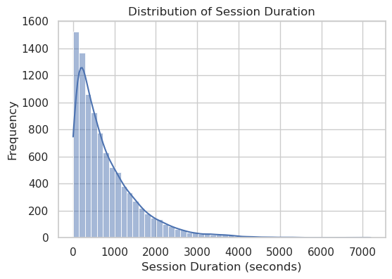

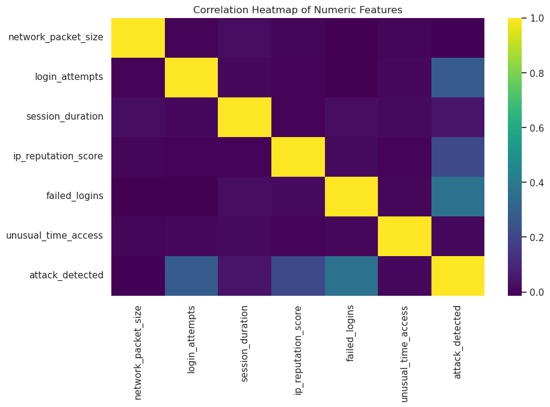

```python
# Plot distribution of the 'session_duration' feature
plt.figure(figsize=(6, 4))
sns.histplot(df['session_duration'], bins=50, kde=True)
plt.title("Distribution of Session Duration")
plt.xlabel("Session Duration (seconds)")
plt.ylabel("Frequency")
plt.show()

# Plot correlation heatmap
numeric_cols = df.select_dtypes(include=np.number).columns
plt.figure(figsize=(10, 6))
sns.heatmap(df[numeric_cols].corr(), cmap='viridis', annot=False)
plt.title("Correlation Heatmap of Numeric Features")
plt.show()
```

## Pre-processing the Data

Effective clustering requires careful pre-processing. Our steps include:

1. **Encoding Categorical Variables:**  
   We will use Label Encoding to transform text-based features such as `protocol_type`, `browser_type`, and `encryption_used` (if treated categorically) into numeric values.
2. **Scaling Numerical Features:**  
   Distance-based algorithms like K-Means require features on a similar scale. Hence, we'll standardize numeric features (e.g., `network_packet_size`, `session_duration`, `login_attempts`, etc.) using StandardScaler.
3. **DataFrame for Clustering:**  
   We will combine the processed numeric and categorical features into a single DataFrame that serves as the input for our clustering algorithms.

Note: We will handle missing values in *encryption_used* appropriately (e.g., leave them as NaN for now or impute if necessary) based on our exploratory analysis.

```python
# Define lists of features for processing (update these lists if needed)
numeric_features = ['network_packet_size', 'login_attempts', 'session_duration', 'ip_reputation_score', 'failed_logins', 'unusual_time_access', 'attack_detected']
# For clustering, we typically exclude the label "attack_detected", but here we'll include it only for later analysis; you might want to exclude it for unsupervised learning.
categorical_features = ['protocol_type', 'browser_type']
# We will treat "encryption_used" separately, here we'll impute missing values with a placeholder (e.g., 'Unknown') before encoding.
df['encryption_used'] = df['encryption_used'].fillna("Unknown")
categorical_features.append('encryption_used')

# Encode all categorical features
for col in categorical_features:
    le = LabelEncoder()
    df[col] = le.fit_transform(df[col])

# Scale numeric features using StandardScaler
scaler = StandardScaler()
df[numeric_features] = scaler.fit_transform(df[numeric_features])

# Create the DataFrame for clustering
clustering_features = ['network_packet_size', 'login_attempts', 'session_duration', 'ip_reputation_score', 'failed_logins'] + categorical_features
df_clustering = df[clustering_features].copy()

print("Sample of Pre-processed Data for Clustering:")
display(df_clustering.head())
```

```
Sample of Pre-processed Data for Clustering:
```

|  | network_packet_size | login_attempts | session_duration | ip_reputation_score | failed_logins | protocol_type | browser_type | encryption_used |
| --- | --- | --- | --- | --- | --- | --- | --- | --- |
| 0 | 0.496899 | -0.016346 | -0.381125 | 1.554930 | -0.500779 | 1 | 1 | 1 |
| 1 | -0.143322 | -0.525794 | 0.972960 | -0.168029 | -1.467959 | 1 | 2 | 1 |
| 2 | 0.648132 | -0.525794 | -0.912503 | 2.301950 | 0.466400 | 1 | 0 | 1 |
| 3 | 1.530327 | -0.016346 | -0.243473 | -1.174443 | -1.467959 | 2 | 4 | 1 |
| 4 | -0.239103 | 0.493102 | -0.330830 | -1.560484 | -0.500779 | 1 | 2 | 0 |

## Modeling (Clustering)

We will now apply two clustering algorithms to our pre-processed data:

1. **K-Means Clustering:**
   - We will determine the optimal number of clusters using the Elbow Method and silhouette scores.
   - K-Means is efficient for large, scaled datasets and works well with spherical clusters.
2. **Agglomerative Clustering:**
   - This hierarchical method offers an alternative view of the data’s structure.
   - Using the 'ward' linkage minimizes within-cluster variance.

Both methods will help us explore how well we can segregate normal network sessions from potential attack sessions.

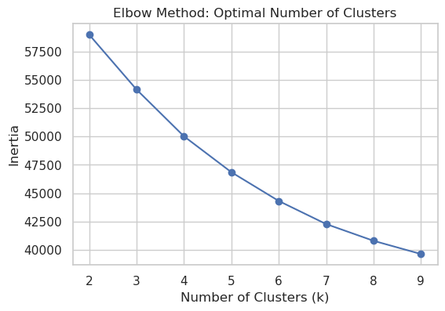

```
k = 2, Silhouette Score = 0.1746
k = 3, Silhouette Score = 0.1623
k = 4, Silhouette Score = 0.1199
k = 5, Silhouette Score = 0.1175
k = 6, Silhouette Score = 0.1183
k = 7, Silhouette Score = 0.1108
k = 8, Silhouette Score = 0.1059
k = 9, Silhouette Score = 0.1065
```

```python
# Prepare the feature matrix for clustering
X = df_clustering.values

# Elbow Method: Compute inertia for a range of cluster numbers using K-Means
inertia_values = []
K_range = range(2, 10)
for k in K_range:
    km = KMeans(n_clusters=k, random_state=42)
    km.fit(X)
    inertia_values.append(km.inertia_)

plt.figure(figsize=(6, 4))
plt.plot(list(K_range), inertia_values, marker='o')
plt.title("Elbow Method: Optimal Number of Clusters")
plt.xlabel("Number of Clusters (k)")
plt.ylabel("Inertia")
plt.show()

# Silhouette Scores for each value of k
for k in K_range:
    km = KMeans(n_clusters=k, random_state=42)
    labels = km.fit_predict(X)
    score = silhouette_score(X, labels)
    print(f"k = {k}, Silhouette Score = {score:.4f}")
```

```python
# Choose an optimal k based on the above results (example: k=2)
k_final = 2
kmeans = KMeans(n_clusters=k_final, random_state=42)
kmeans_labels = kmeans.fit_predict(X)

print("K-Means Cluster Distribution:")
print(pd.Series(kmeans_labels).value_counts())
```

```
K-Means Cluster Distribution:
1    6606
0    2931
Name: count, dtype: int64
```

```python
# Apply Agglomerative Clustering with the same number of clusters
agglo = AgglomerativeClustering(n_clusters=k_final, linkage='ward')
agglo_labels = agglo.fit_predict(X)

print("Agglomerative Clustering Distribution:")
print(pd.Series(agglo_labels).value_counts())

# Evaluate Agglomerative Clustering with the silhouette score
agglo_sil_score = silhouette_score(X, agglo_labels)
print(f"Agglomerative Clustering Silhouette Score: {agglo_sil_score:.4f}")
```

```
Agglomerative Clustering Distribution:
0    6262
1    3275
Name: count, dtype: int64
Agglomerative Clustering Silhouette Score: 0.1338
```

## Storytelling: Clustering Analysis

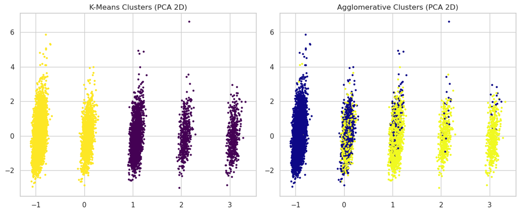

```python
# Reduce dimensions using PCA for visualization
pca = PCA(n_components=2)
X_pca = pca.fit_transform(X)

# Plot clustering results for both algorithms side by side
fig, axes = plt.subplots(1, 2, figsize=(12, 5))

# K-Means Clustering Visualization
scatter1 = axes[0].scatter(X_pca[:, 0], X_pca[:, 1], c=kmeans_labels, cmap='viridis', s=5)
axes[0].set_title("K-Means Clusters (PCA 2D)")

# Agglomerative Clustering Visualization
scatter2 = axes[1].scatter(X_pca[:, 0], X_pca[:, 1], c=agglo_labels, cmap='plasma', s=5)
axes[1].set_title("Agglomerative Clusters (PCA 2D)")

plt.tight_layout()
plt.show()
```

## Impact Section

**Potential Benefits:**

- **Automated Anomaly Detection:**  
  Clustering helps highlight unusual network sessions that may indicate emerging cyber threats, reducing the burden of manual monitoring.
- **Operational Efficiency:**  
  By grouping similar network behaviors, system administrators can focus on investigating clusters of anomalous activity.

**Potential Challenges and Ethical Considerations:**

- **False Positives/Negatives:**  
  Incorrect cluster assignments may lead to legitimate sessions being flagged as attacks (and vice versa), affecting operational decisions.
- **Dataset Limitations:**  
  The dataset's age and composition may not fully capture modern attack techniques.
- **Privacy Concerns:**  
  Handling and analyzing network data, especially in real-world applications, requires attention to data privacy and protection measures.

Overall, while the clustering approach shows promise, further refinements and complementary techniques would be necessary for deployment in operational settings.

## References

1. Tavallaee, M., Bagheri, E., Lu, W., & Ghorbani, A. A. (2009). *A Detailed Analysis of the KDD CUP 99 Data Set*. In Proceedings of the IEEE Symposium on Computational Intelligence for Security and Defense Applications (CISDA), 1–6.
2. Jain, A. K., Murty, M. N., & Flynn, P. J. (1999). *Data Clustering: A Review*. ACM Computing Surveys, 31(3), 264–323.
3. scikit-learn: Machine Learning in Python. Retrieved from https://scikit-learn.org/stable/
4. Chandola, V., Banerjee, A., & Kumar, V. (2009). *Anomaly Detection: A Survey*. ACM Computing Surveys, 41(3), Article 15.
5. dnkumars, Cybersecurity Intrusion Detection Dataset. Retrieved from [Kaggle – dnkumars/cybersecurity-intrusion-detection-dataset](https://www.kaggle.com/dnkumars/cybersecurity-intrusion-detection-dataset)